# HIV testing uptake among women in South Africa

Dickman Pangaume Gareta

2023-12-22

# Introduction

HIV is a public health concern worldwide and efforts are underway to eliminate the virus by 2030. However, knowing one’s HIV status is crucial as it provides an entry point into HIV care, treatment and lifelong support. This is especially important in regions with the highest burden of HIV such as the Sub-Saharan Africa. There is documented evidence that HIV incidence is high among women especially those in the older age groups. Therefore, understanding HIV status among women is key in preventing the acquisition of the disease or linking to HIV care and treatment.

The objective of the capstone project is to evaluate the uptake of HIV testing by social demographic factors among women aged between 15 and 49 years in South Africa. The data source for this analysis is the *2016 South Africa Demographic and Health Surveys(DHS)*. More info about the survey can be found [here](https://dhsprogram.com/data/Guide-to-DHS-Statistics/).

# Background characteristics

This section describes HIV testing in the study population in terms of the following key areas:

- Social demographic characteristics
- Sexual relationships
- Access to information

## Social demographic characteristics

A total of 8514 women were interviewed during the 2016 Demographic and Health Survey in South Africa. Of these, 7136 (84%) reported to have had HIV test before. Women who ever tested for HIV were older (31 years(IQR :15)) than those who never tested for HIV (19 years (IQR : 14)).

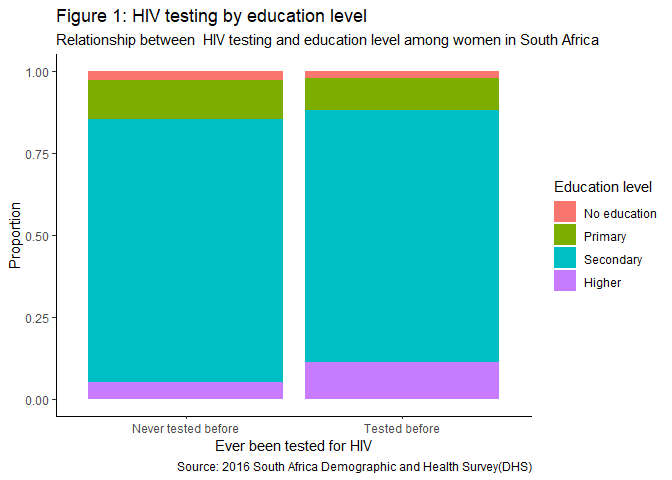

A total of 4067(57%) women who reported to have had an HIV test before resided in the rural areas while 738(54%) women who reported not have had an HIV test resided in the rural areas(**Figure 2**).

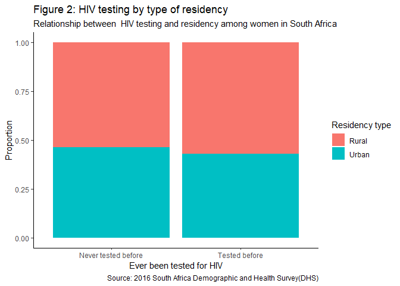

Of the women who reported to have had an HIV test before, 1572(22%) were from middle-class households. Similarly for those who never had an HIV test before, 314(23%) women were from middle-class households (**Figure 3**).

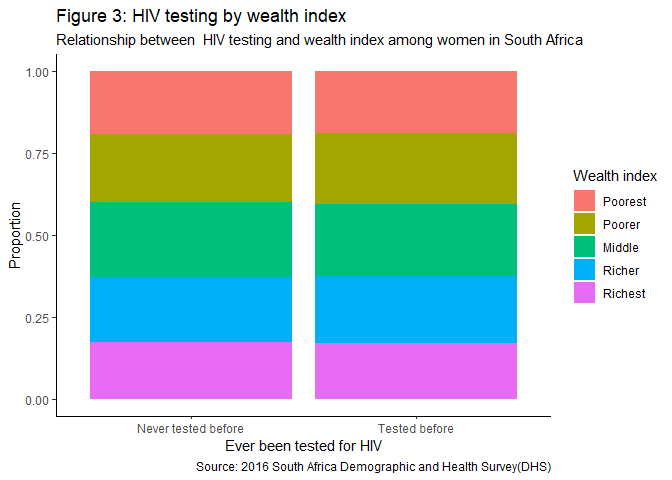

## Sexual relationships

Majority of the women who had never had HIV test before reported to have never had any sex before compared to those who had an HIV test(**Figure 4**). Among women who reported to have had an HIV test before, 3635(51%) were sexually active compared to 312(23)% among those who reported to have never had an HIV test.

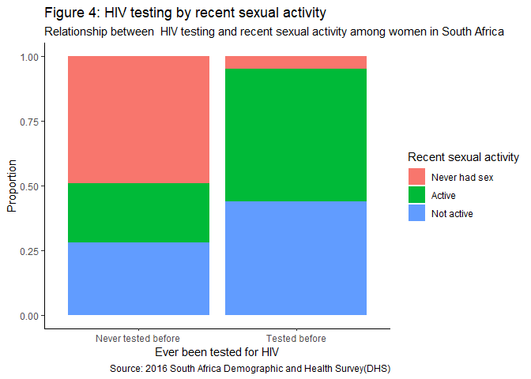

Of the women who reported to have had an HIV test before, 3998(56%) women reported to have never been married before compared to 1136(82%) among those who reported to have never had an HIV test(**Figure 5**).

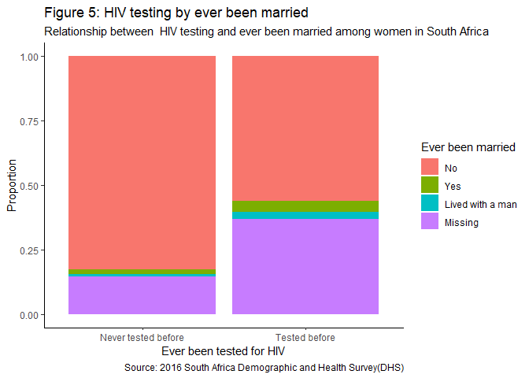

A total of 1221(17%) women who reported to have had an HIV test before had used a condom during their recent sexual encounter while 804(58%) women who reported not have had an HIV test reported the use of a condom during their recent sexual encounter.

## Access to information

Among women who reported to have had an HIV test before, 3223(45%) women reported to have used internet before compared to 663(48)% women among those who reported to have never had an HIV test(**Figure 6**).

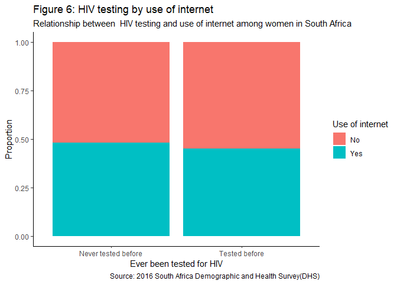

A total of 3981(56%) women who reported to have had an HIV test had access to the radio compared to 813(59%) women who reported not have had an HIV test(**Figure 7**).

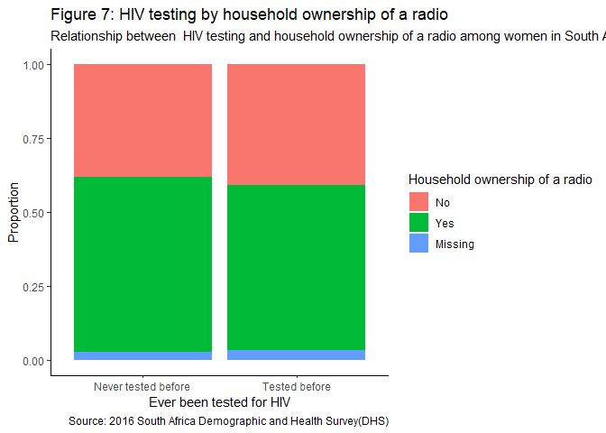

5462(77%) women who reported to have had an HIV test had access to the TV compared to 1071 (78%) women who reported not have had an HIV test(**Figure 8**).

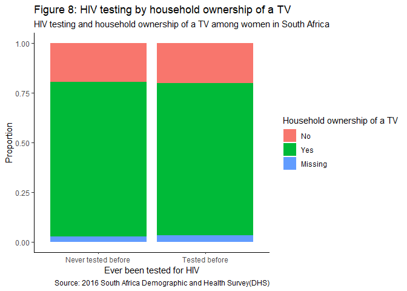

# Distribution of body mass index and hemoglobin by HIV testing status

This section describes distributions of the following:

- Body mass index by HIV testing status
- Hemoglobin by HIV testing status
- Hemoglobin and BMI stratified by HIV testing status

## Body mass index by HIV testing status

Those who reported to have had an HIV test before had a slightly higher body mass index compared to those who had not had an HIV test before (**Figure 9**).

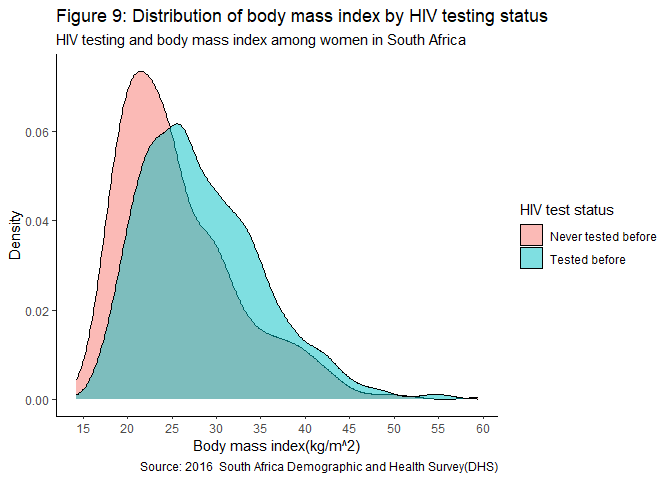

## Hemoglobin by HIV testing status

There was no noticeable difference in hemoglobin levels between those who reported to have had an HIV test before and those who did not have an HIV test(**Figure 10**).

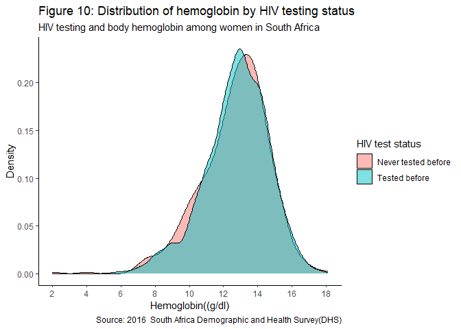

## Hemoglobin and BMI stratified by HIV testing status

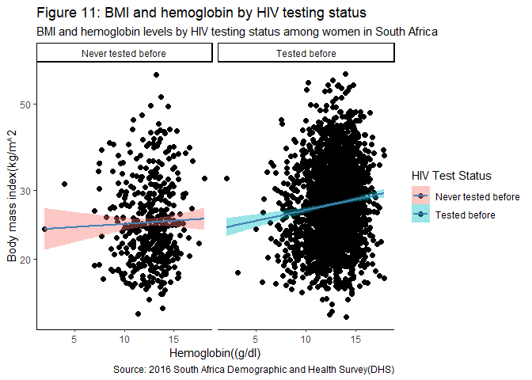

# HIV testing by age stratified by social economic status

This section plots the following relationships:

- HIV testing by age stratified by type of residence
- HIV testing by age stratified by wealth index
- HIV testing by age stratified by education level

## HIV testing by age stratified by type of residence

The median ages for women who reported to have tested for HIV were higher than those who reported not have tested for HIV in both rural and urban areas(**Figure 12**).

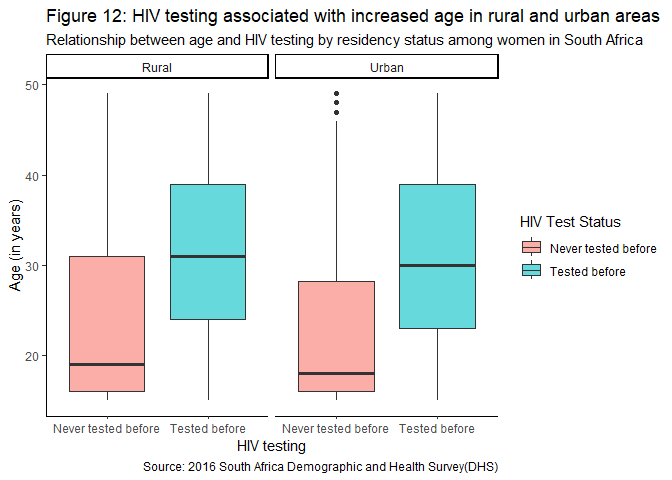

## HIV testing by age stratified by wealth index

The median ages for those who tested for HIV were likely to be greater than the median ages for those who did not test for HIV across different wealth quintiles(**Figure 13**).

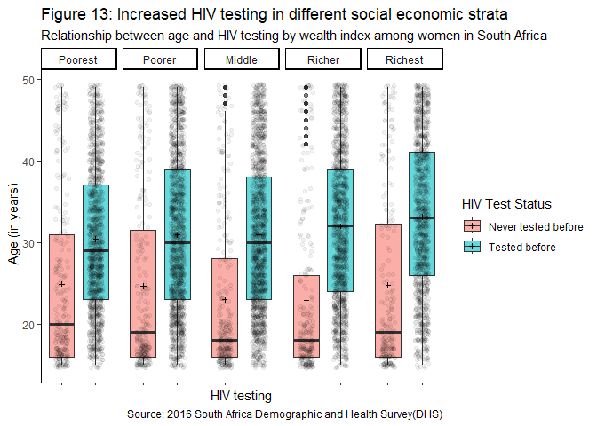

## HIV testing by age stratified by education level

Except the category with no education, the median ages for those who tested for HIV were likely to be greater than the median ages for those who did not test for HIV across different education levels(**Figure 14**).

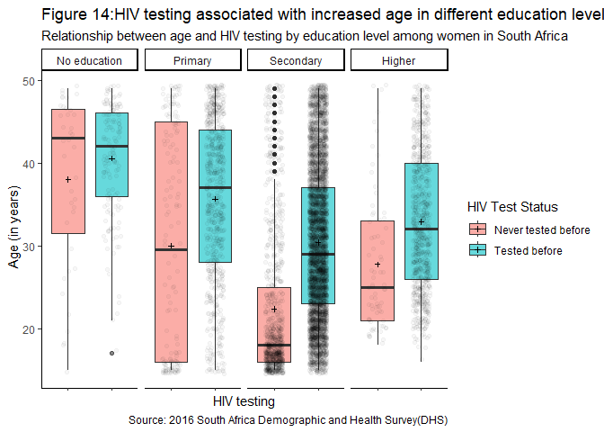

# Analytical results

The analytical results of this project look at the association of HIV testing with social demographic variables. In the univariable analysis, a logitsic regression model is fitted with individual variables.In the multivariable analysis, all the variables are included in the model.

## Univariable analysis

In brief, the univariable models showed the following results:

- HIV testing uptake increased with age
- HIV testing uptake decreased as the level of wealth quintile of the individual increased
- Urban dwellers were less likely test compared to the rural residents
- HIV testing uptake increased with level of education
- Women who were married or living with a partner were more likely to test compared to those who had never been married before
- Women who were sexually active or previously sexually active were more likely to test than those who had never had sex before
- Women from households with a radio were less likely to test for HIV compared those from households without a radio
- Women from households with a TV were less likely to test for HIV compared those from households without a TV
- Women who had used internet before were less likely to test for HIV compared those who had never used internet before

## Multivariable analysis

After adjusting for the other confounding variables in the model:

- HIV testing uptake significantly increased with age
- HIV testing uptake significantly increased wealth quintile of the individual
- Urban dwellers were significantly less likely to test compared to the rural residents
- HIV testing uptake significantly increased with level of education
- Women who were married or living with a partner were significantly more likely to test compared to those who had never been married before
- Women who were sexually active or previously sexually active were more significantly likely to test than those who had never had sex before

# Conclusions

The recommendation for this capstone project is to encourage interventions aimed at increasing awareness of the HIV testing through radio, TV or social media. Interventions should also be aimed at increasing education among women.

# Reference

- [R Graph courses: A Data Science Training Platform for Health Professionals](https://thegraphcourses.org/)
- [The DHS Program: Demographic and Health Surveys](https://dhsprogram.com/)